# Chapter 4: Geocentric Models

Quang Nguyen

10/3/2020

```r
library(rethinking)
library(glue)
library(tidyverse)
```

#### Text-book code for Gaussian modelling of height.

```r
data("Howell1")
d <- Howell1
d2 <- d %>% filter(age >= 18)
mu.list <- seq(from=150, to=160, length.out = 100)
sigma.list <- seq(from = 7, to = 9, length.out = 100)
post <- expand.grid(mu = mu.list, sigma = sigma.list)

# calculate likelihood from grid of values
post$LL <- sapply(1:nrow(post), function(x){
  sum(dnorm(d2$height, post$mu[x], post$sigma[x], log = TRUE))
})

# evaluate numerator as likelihood combined with prior
post$prod <- post$LL + dnorm(post$mu, 170, 20, TRUE) + dunif(post$sigma, 0, 50, TRUE)

# normalize by maximum
post$prob <- exp(post$prod - max(post$prod))

print("Contour plots")
```

```
## [1] "Contour plots"
```

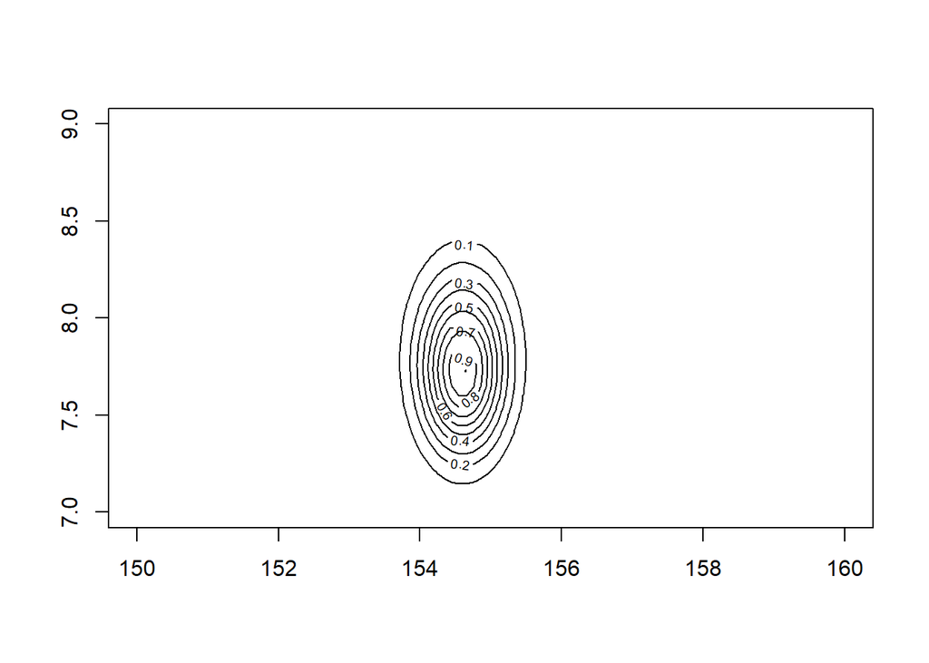

```r
contour_xyz(post$mu, post$sigma, post$prob)
```

```r
print("Heatmap")
```

```
## [1] "Heatmap"
```

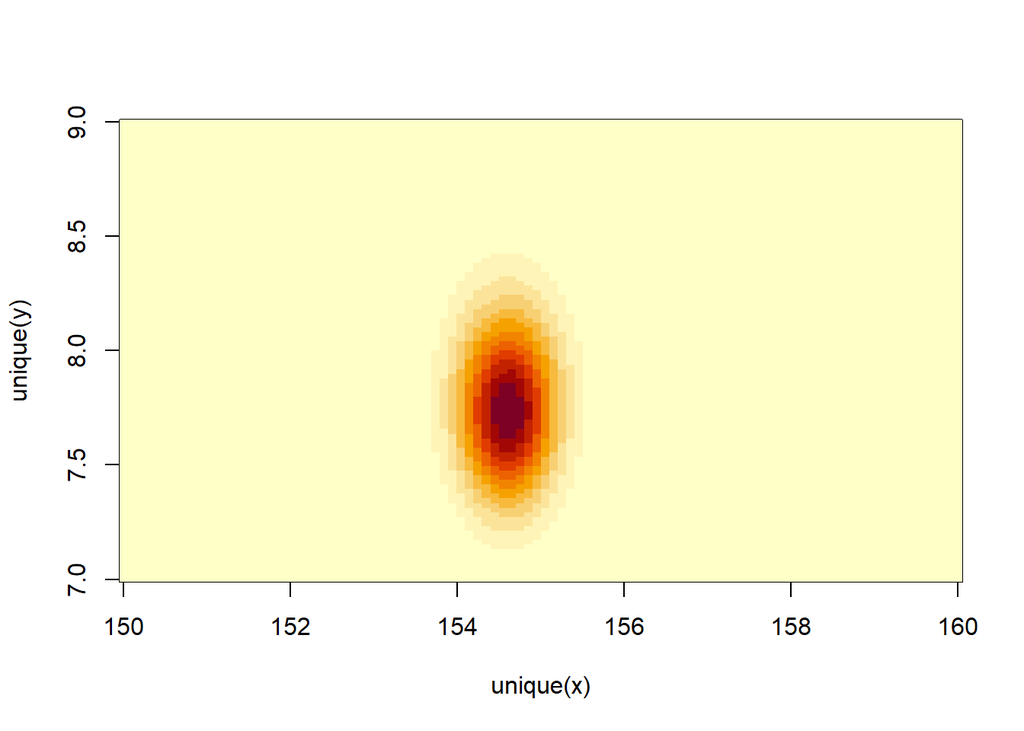

```r
image_xyz(post$mu, post$sigma, post$prob)
```

#### Sampling from the posterior

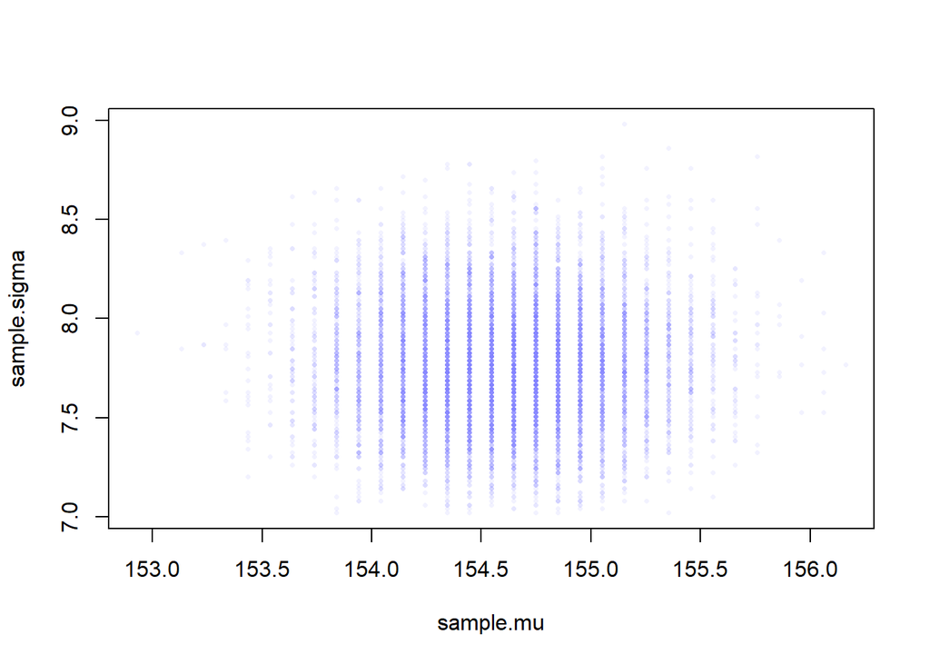

```r
# sampling rows based on posterior
sample.rows <- sample(1:nrow(post), size = 1e4, replace = T, prob = post$prob)

# retrieve parameter values
sample.mu <- post$mu[sample.rows]
sample.sigma <- post$sigma[sample.rows]

plot(sample.mu, sample.sigma, cex = 0.5, pch = 16, col = col.alpha(rangi2,0.1))
```

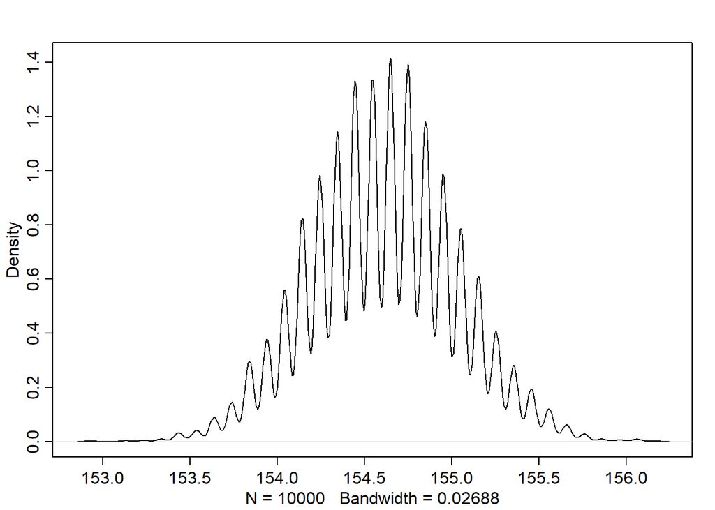

```r
# Marginal distribution
dens(sample.mu)
```

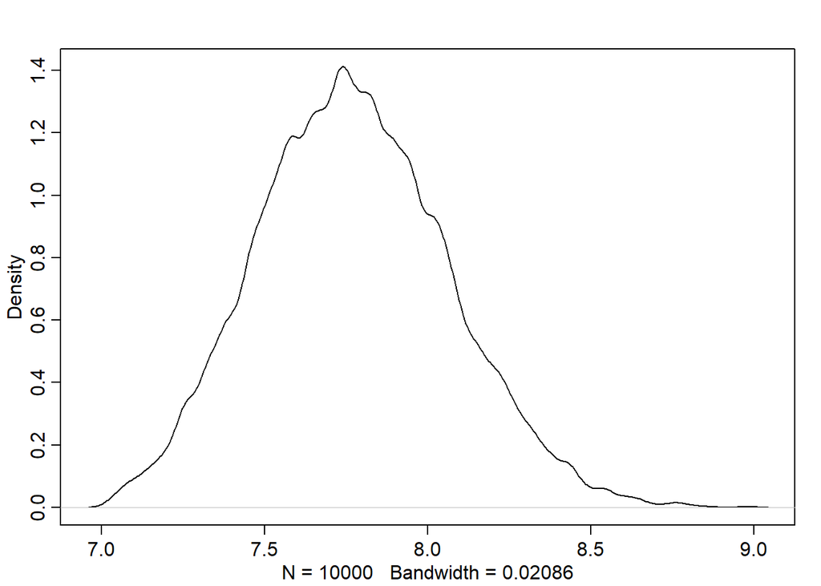

```r
dens(sample.sigma)
```

```r
PI(sample.mu)
```

```
##       5%      94%
## 153.9394 155.2525
```

```r
PI(sample.sigma)
```

```
##       5%      94%
## 7.323232 8.252525
```

#### Using the quadratic approximation

```r
flist <- alist(
  height ~ dnorm(mu, sigma),
  mu ~ dnorm(178,20),
  sigma ~ dunif(0,50)
)

m4.1 <- quap(flist, data = d2)
precis(m4.1)
```

```
##             mean        sd       5.5%      94.5%
## mu    154.607278 0.4120006 153.948821 155.265734
## sigma   7.731444 0.2913965   7.265736   8.197152
```

`quap` estimates posterior distribution by approximation. It needs a start point to start the gradient procedure, which will be chosen at random from the prior if start values are not specified. Use `alist` when defining a list of formulas because alist does not evaluate terms in the list.

#### Using quadratic approximation with a more informative prior

```r
m4.2 <- quap(
  alist(
    height ~ dnorm(mu, sigma),
    mu ~ dnorm(178, 0.1),
    sigma ~ dunif(0,50)
  ), data = d2
)

precis(m4.2)
```

```
##            mean        sd      5.5%     94.5%
## mu    177.86376 0.1002354 177.70356 178.02395
## sigma  24.51757 0.9289238  23.03297  26.00217
```

#### Sampling from quap

```r
post <- extract.samples(m4.1, n = 1e4)
precis(post)
```

```
##             mean        sd       5.5%      94.5%
## mu    154.616259 0.4102151 153.970811 155.268397
## sigma   7.728563 0.2937433   7.262166   8.194917
##                                                                                                      histogram
## mu                                                    ▁▁▅▇▂▁▁
## sigma ▁▁▁▁▂▅▇▇▃▁▁▁▁
```

#### Linear prediction

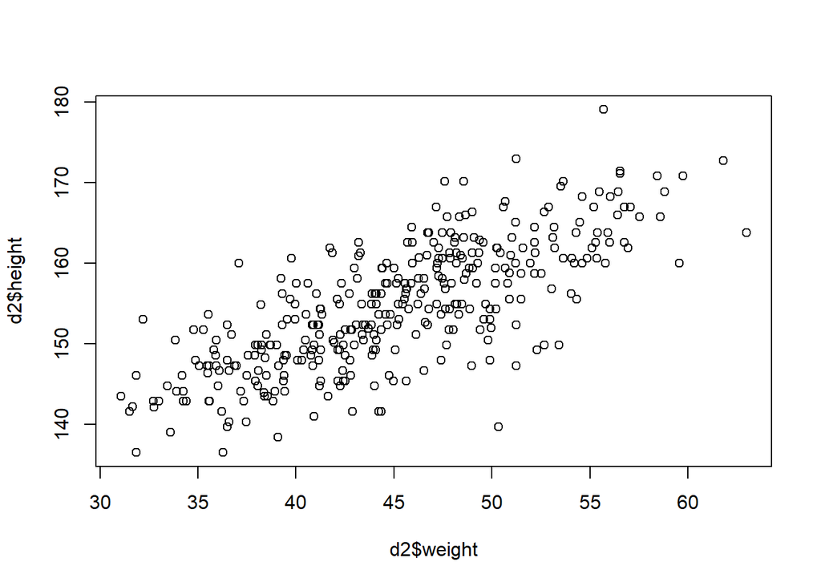

```r
plot(d2$height ~ d2$weight)
```

Simulating to get the prior.

```r
N <- 100
a <- rnorm(N, 178, 20)
b <- rnorm(N, 0, 10)
b2 <- rlnorm(N, 0, 1)
xbar <- mean(d2$weight)
print("Getting the normal prior")
```

```
## [1] "Getting the normal prior"
```

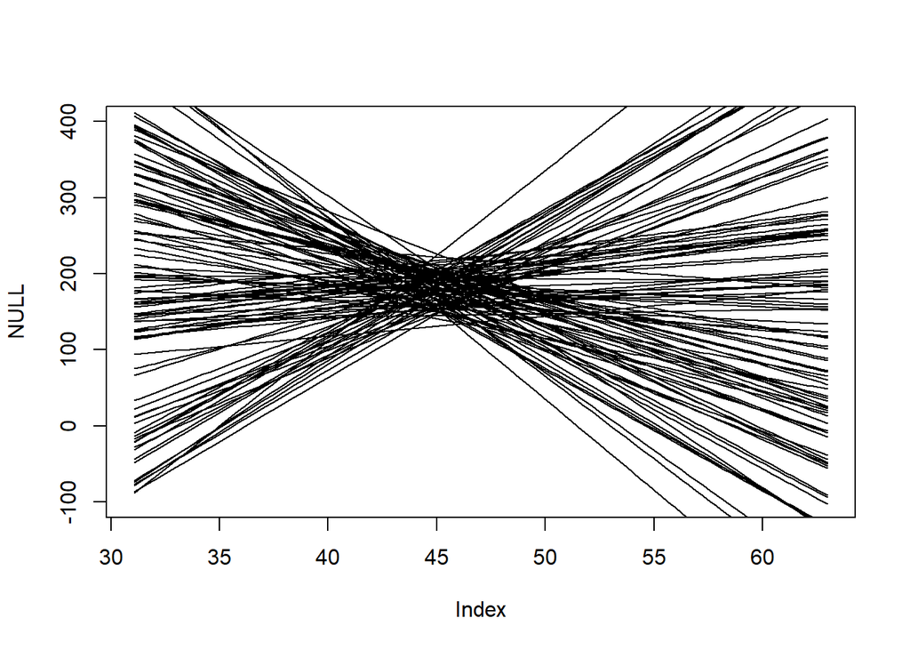

```r
plot(NULL, xlim = range(d2$weight), ylim = c(-100,400))
for (i in 1:N){
  curve(a[i] + b[i]*(x - xbar), from = min(d2$weight),
        to=max(d2$weight),add = TRUE)
}
```

```r
print("Getting the log-normal prior")
```

```
## [1] "Getting the log-normal prior"
```

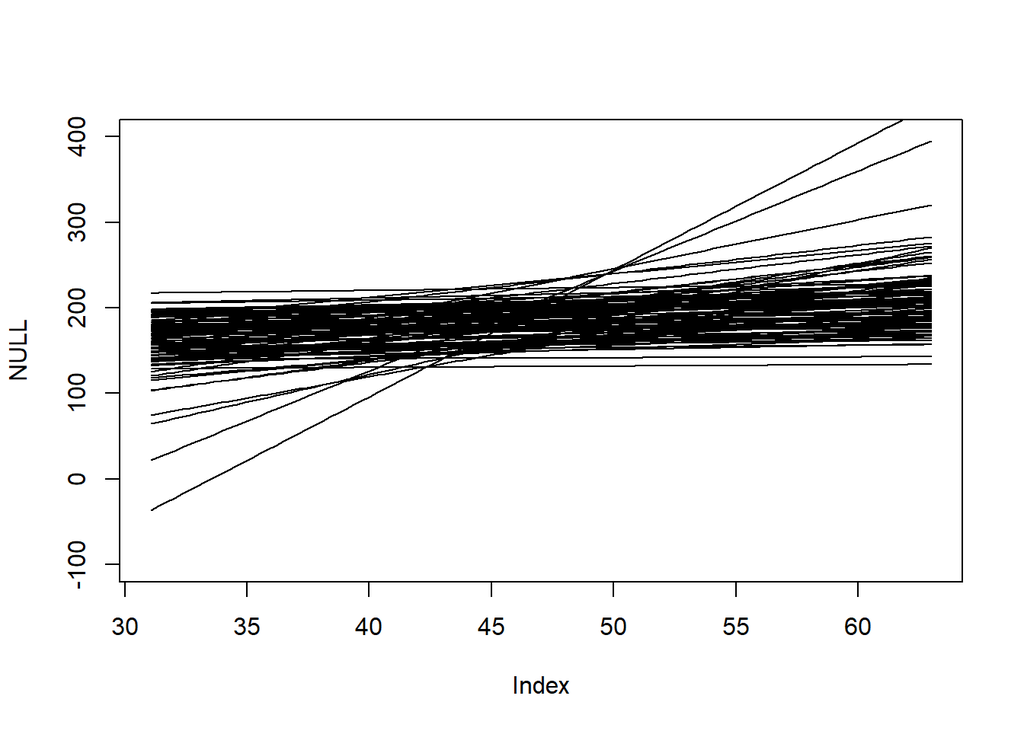

```r
plot(NULL, xlim = range(d2$weight), ylim = c(-100,400))
for (i in 1:N){
  curve(a[i] + b2[i]*(x - xbar), from = min(d2$weight),
        to=max(d2$weight),add = TRUE)
}
```

We fuss about priors for two reasons:  
1. There are many analyses in which no amount of data makes the prior irrelevant. Non Bayesian methods also depend on such structural assumptions and are no better off.  
2. Second, thinking about priors helps us develop better models, maybe even eventually going beyond geocentricism.

**Rethinking: What is the correct prior?** People often assume that there is a uniquely correct prior, which is wrong. Priors can be wrong in the same way that a hammer can be wrong for building a table. There exists guidelines to chose priors. Priors encode data and information before seeing data. Priors allow us to see consequences of beginning with different information. We can use priors to discourage certain parameter values such as negative associations between height and weight. When we don’t know that much, we still now some information about the plausible range of values.

**Rethinking: Prior predictive simulation and p-hacking** If we choose to evaluate our choice of priors on observed data, that’s cheating. The procedure performed is to try to choose priors based on pre-data knowledge. We’re judging our choice of prior on general facts, not the sample.

Back to our regression model of weight and height which we have as:
$$h_i \sim Normal(\mu_i, \sigma)$$
$$\mu_i = \alpha + \beta(x_i - \bar{x})$$
$$\alpha \sim Normal(178,20)$$
$$\beta \sim Log-Normal(0,1)$$
$$\sigma \sim Uniform(0,50)$$
We can encode this to our model

```r
m4.3 <- quap(
  alist(
    height ~ dnorm(mu, sigma),
    mu <- a + b*(weight - xbar),
    a ~ dnorm(178,20),
    b ~ dlnorm(0,1),
    sigma ~ dunif(0,50)
  ), data = d2
)
```

#### Interpreting the posterior distribution

We can learn about our model results either via tables or via simulation plotting. Tables aren’t too great, however, at understanding complex models. In this book we’re going to focus on plotting the posterior distributions and posterior predictions.  
**Rethinking: What do parameters mean?** The perspective of this book is: *Posterior probabilities of parameter values describe the relative compatiability of different states of the world with the data, according to the model.

First, let’s observe a table of marginals

```r
precis(m4.3)
```

```
##              mean         sd        5.5%       94.5%
## a     154.6013675 0.27030764 154.1693637 155.0333713
## b       0.9032809 0.04192363   0.8362788   0.9702829
## sigma   5.0718806 0.19115475   4.7663784   5.3773828
```

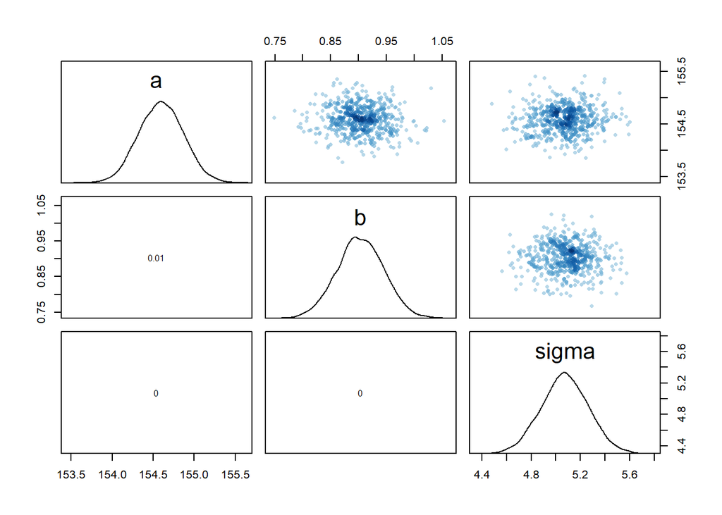

```r
pairs(m4.3)
```

Plotting the posterior distribution against the data can provide an informal check on assumptions. But more importantly it provides a way to interpret the posterior, especially as models get complicated with interactions and non-linear terms.

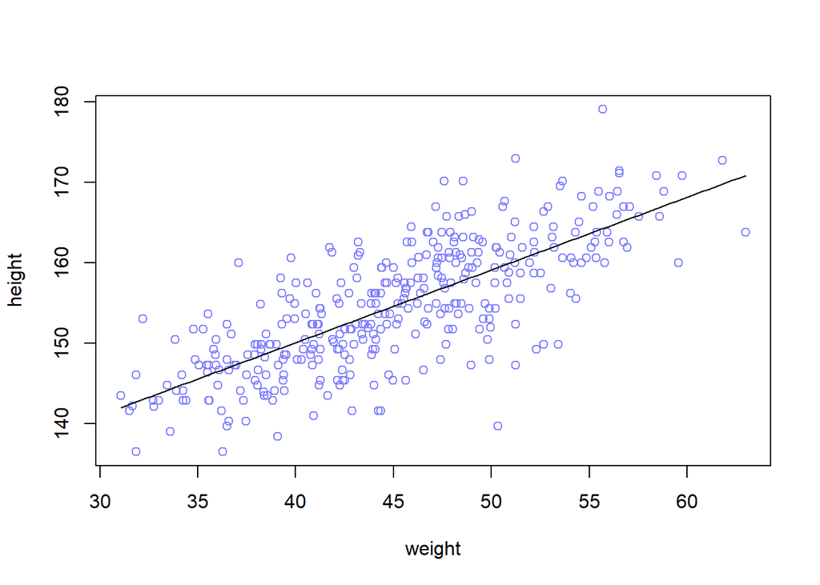

```r
plot(height ~ weight, data = d2, col = rangi2)
post <- extract.samples(m4.3)
a_map <- mean(post$a)
b_map <- mean(post$b)
curve(a_map + b_map*(x - xbar), add = T)
```

The line we just draw is the posterior mean line and does not capture the uncertainty of the estimates. We can do so by plotting multiple regression lines.

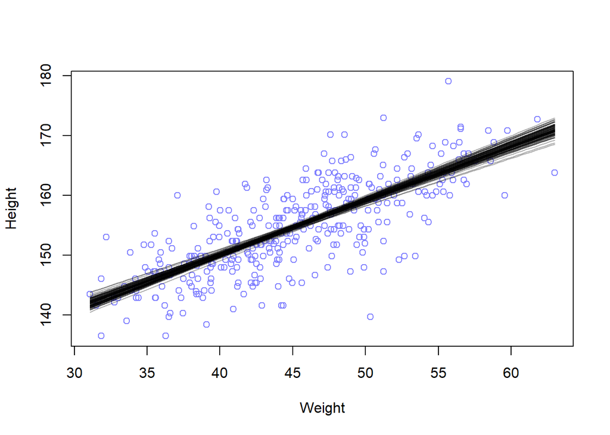

```r
post <- extract.samples(m4.3, n=100)
plot(d2$weight, d2$height, xlim = range(d2$weight), ylim = range(d2$height), col = rangi2,
     xlab = "Weight", ylab = "Height")
for (i in 1:nrow(post)){
  curve(post$a[i] + post$b[i]*(x - mean(d2$weight)), col = col.alpha("black", 0.3), add = T)
}
```

The uncertainty decreases as we increase the sample size. Since $\mu$ is a combination of random variables with distributions, $\mu$ has a distribution. For every value of $x$ weight, we can get all possible values of $\mu$ as a joint distribution of values of $\alpha$ and $\beta$. This distribution incorporates both the individual variabilities of $\alpha$ and $\beta$ as well as any correlation between the variables (joint Gaussian distribution). We can construct an interval for values of height at each values of weight according to our posterior distribution. If we do so for every point of weight in the sample, we can conduct a confidence band for our regression model.

```r
weight.seq <- seq(25, 70, 1)
mu <- link(m4.3, data = data.frame(weight = weight.seq))
str(mu) # This samples from the posterior of height for each value in weight.seq from the model
```

```
##  num [1:1000, 1:46] 136 135 137 137 138 ...
```

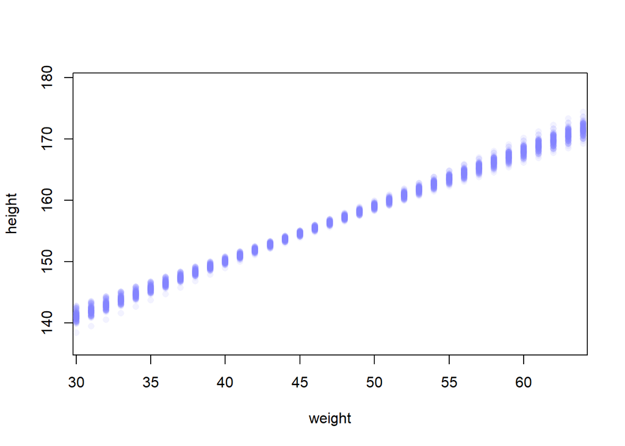

```r
plot(height ~ weight, d2, type = "n")
for(i in 1:100){
  points(weight.seq, mu[i,], pch = 16, col = col.alpha(rangi2,0.1))
}
```

We can summarize the posterior distribution as interval estimates and the mean

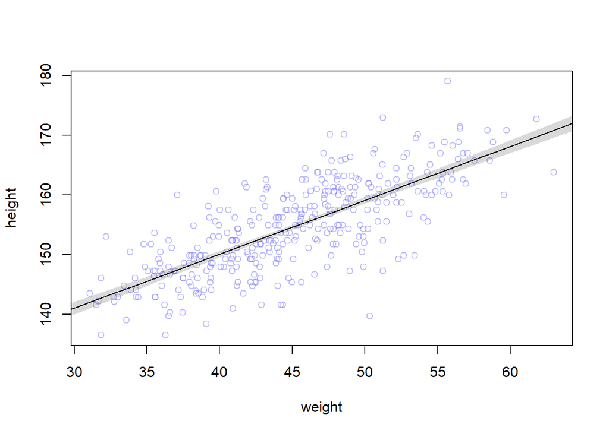

```r
mu.mean <- apply(mu, 2, mean)
mu.PI <- apply(mu, 2, PI, prob = 0.89)
plot(height~weight, data = d2, col = col.alpha(rangi2, 0.5))
lines(weight.seq, mu.mean)
shade(mu.PI, weight.seq)
```

These intervals are great but they’re very tight around the posterior mean (MAP). This is because the inferences are always conditional on the model. Even bad models can have tight compatibility intervals. In other words, this line can be thought of as “conditional on the assumption that height and weight are linearly related by a straight line, then this is the most plausible line”

Some ways we can generate predictions and posterior from a fitted model:  
(1) Use a function (in this case `link`) to generate distributions of posterior values for your parameter $\mu$ for each combination of values from your predictors of interest (in this case, weight).  
(2) Use summary functions like `mean` and `PI` to find averages and lower and upper bounds for $\mu$ for each value of the predictor variable  
(3) Use plotting functionality to draw lines and intervals with respect to the real data.

#### Prediction intervals

The goal of the model in the prediction sense is not to estimate the average height but more specific heights. The way to do it is: for any unique weight value, you can sample from a Gaussian distribution with the correct mean for that weight, using the value of sigma sampled from the sample posterior distribution. If you do this for every sample from the posterior and every weight value, you can get estimates that incorporates both the uncertainty of the Gaussian distribution, as well as the uncertainty of the posterior.

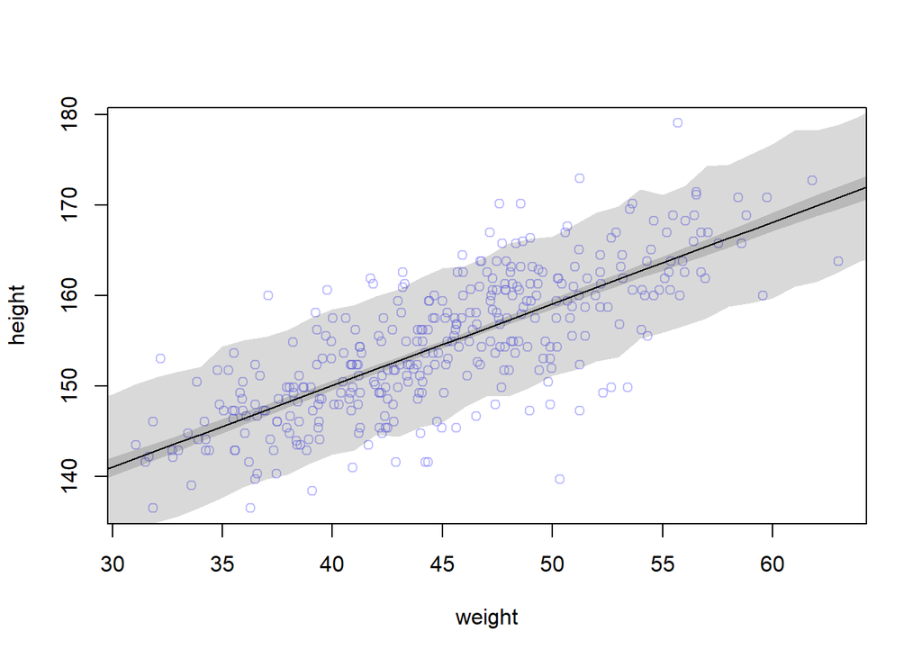

```r
sim.height <- sim(m4.3, data = list(weight = weight.seq))
height.PI <- apply(sim.height, 2, PI, prob = 0.89)
mu.HPDI <- apply(mu, 2, HPDI, prob = 0.89)
plot(height ~ weight, d2, col = col.alpha(rangi2, 0.5))
lines(weight.seq, mu.mean)
shade(mu.HPDI, weight.seq)
shade(height.PI, weight.seq)
```

### 4.5 Curve from lines